# 260-2015-11-06-action-I

2015-11-08 09:13:37

## Prelude

[video not shown]

## Today's Topics

- The neuroscience of movement [continued](https://rawgit.com/psu-psychology/psych-260/master/lectures/2015-11-06/260-2015-11-06-action-I.html#17)

## The Real Reason for Brains

[interactive chart not shown]

## The cognitive neuroscience of action

- What types of actions are there?
- How are they produced?
  - By the muscles
  - By the nervous system

## Remember

- Nervous system "output" includes
  - Movements
  - Autonomic responses
  - Endocrine responses

## Types of actions

[figure not shown]

http://www.kidport.com/reflib/science/humanbody/muscularsystem/images/Reflexes.jpg

## Types of actions

- Reflexes
  - Simple, highly stereotyped, unlearned, rapid
- Planned or voluntary actions
  - Complex, flexible, acquired, slower
- Discrete (reaching) vs. rhythmic (walking)
- Ballistic (no feedback) vs. controlled (feedback)

## Multiple, parallel controllers

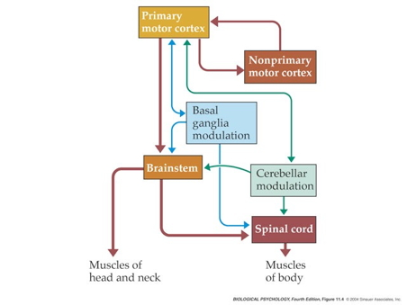

## Key "nodes" in network

- Primary motor cortex (M1)
- Non-primary motor cortex
- Basal ganglia
- Brain stem
- Cerebellum
- Spinal cord

## Muscle classes

- Axial
  - Trunk, neck, hips
- Proximal
  - Shoulder/elbow, pelvis/knee
- Distal
  - Hands/fingers, feet/toes

## Muscles

[figure not shown]

http://classroom.sdmesa.edu/eschmid/F08.12a.L.150.jpg

## Muscle types

- Smooth
  - Arteries, hair follicles, uterus, intestines
  - Regulated by ANS (involuntary)
- Striated (striped)
  - Skeletal
  - Voluntary control, mostly connected to tendons and bones
- Cardiac

## Muscle types

[figure not shown]

http://graphics8.nytimes.com/images/2007/08/01/health/adam/19917.jpg

## How skeletal muscles contract

- Motoneuron (ventral horn of spinal cord)
- Neuromuscular junction
  - Release ACh

## From spinal cord to muscle

[figure not shown]

## How skeletal muscles contract

- Motor endplate
  - Nicotinic ACh receptor
- Excitatory endplate potential
  - Muscle fibers depolarize
  - Depolarization spreads along sarcomere like an action potentail
  - Intramuscular stores release Ca++

## Motor endplate

[figure not shown]

http://www.siumed.edu/~dking2/ssb/images/NM040b.jpg

## How skeletal muscles contract

- Myofibrils (w/in muscle fibers)
  - Actin & mysosin proteins
  - “Molecular gears”
- Bind, move, unbind in presence of Ca++, ATP

## Anatomy of muscle fibers

[figure not shown]

## Anatomy of motor endplate

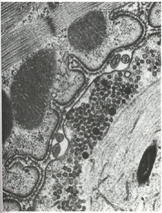

## Muscle contraction

[video not shown]

## Agonist/antagonist muscle pairs

[figure not shown]

http://2.bp.blogspot.com/-TpOC4my_NBc/T0J-MhEv29I/AAAAAAAAF88/dYLv7QzFwmg/s1600/Hamstring-Quad4.jpg

## Meat preference?

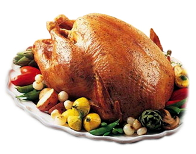

## Muscle fiber types

- Fast twitch/fatiguing
  - Type II
  - White meat
- Slow twitch/fatiguing
  - Type I
  - Red meat

## Next time

- Muscles are sensory organs, too!
- Motor pathways